# MECH476: Engineering Data Analysis in R

Chapter 7 Homework: Multivariate Exploratory Data Analysis

Tyson Williams

22 October, 2025

# Chapter 7 Homework

In [Chapter 5](https://smogdr.github.io/edar_coursebook/eda1.html#cumulative-distribution-plot), we briefly explored data on the salaries of engineering graduates from the National Science Foundation 2017 [National Survey of College Graduates](https://www.nsf.gov/statistics/srvygrads/) from a univariate perspective. Now, let’s explore the relationships between multiple variables.

When a question asks you to make a plot, remember to set a theme, title, subtitle, labels, colors, etc. It is up to you how to personalize your plots, but put in some effort, and make the plotting approach consistent throughout the document. For example, you could use the same theme for all plots. I also like to use the subtitle as a place for the main summary for the viewer.

## Question 1: Data wrangling

Within a pipeline, import the data from the .csv file, convert all column names to lowercase text (either “manually” with `dplyr::rename()`, or use [`clean_names()` from the `janitor` package](https://rdrr.io/cran/janitor/man/clean_names.html)), convert `gender` from “numeric” to “factor”, and drop any and all observations with `salary` recorded as 0. Assign this to a dataframe object with a meaningful name.

How many observations have a 0 (zero) value for salary? Note: The last question asked you to remove these observations from the resultant data frame.

```
## [1] 15
```

What are the levels in `gender`? (Ignore the fact that the observations refer to “biological sex”, not “gender”. *Gender* is now recognized as a fluid term with more than two options; *biological sex* - what was assigned at birth - is binary term).

```
## [1] "F" "M"
```

## Question 3: Multivariate histograms

Create a histogram of `salary`, faceted by `gender`. Add `bins = 50` and `color = "lightgrey"`.

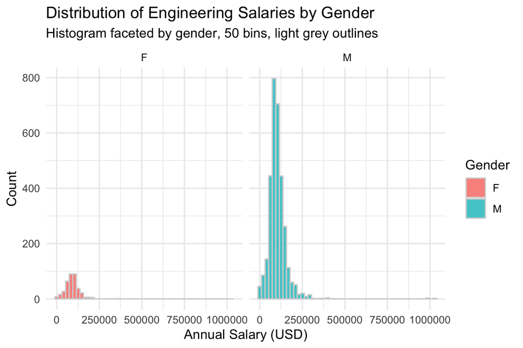

Create a histogram of `age`, faceted by `gender`. Add `bins = 50` and `color = "lightgrey"`.

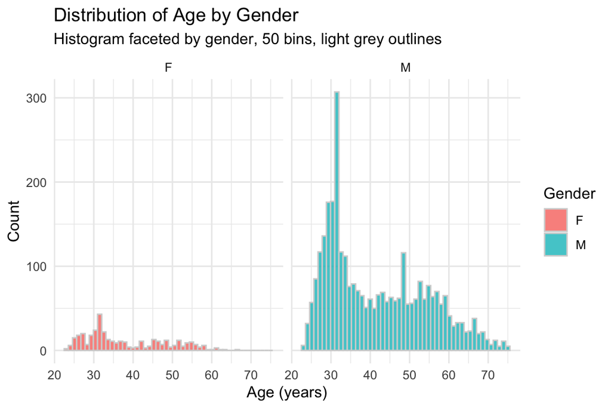

## Question 4: Multivariate boxplots

Create a boxplot of `salary`, faceted by `gender`. Use `oulier.shope = 1` to better visualize the outliers.

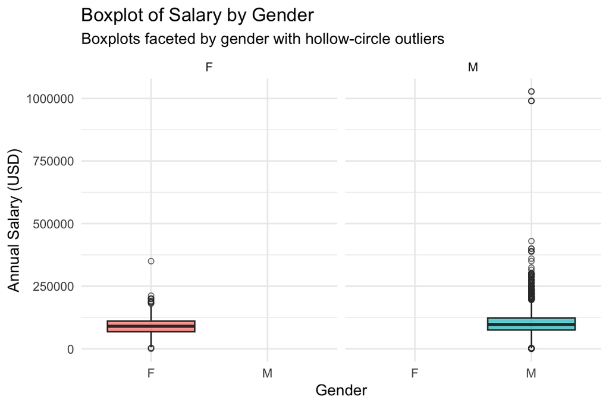

Create a boxplot of `age`, faceted by `gender`.

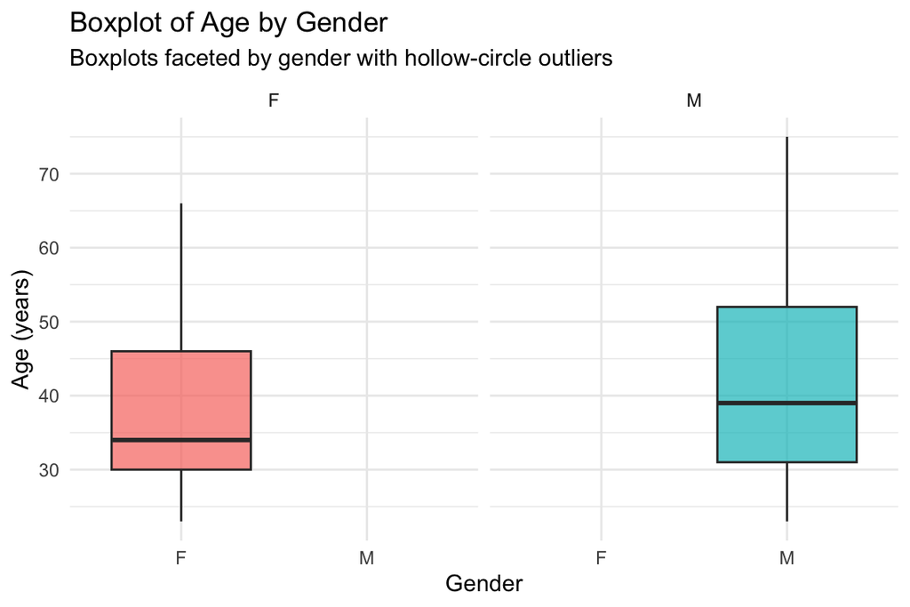

## Question 5: Scatterplot and correlation

Create a scatterplot of `age` (x-axis) and `salary`, differentiating by `gender`.

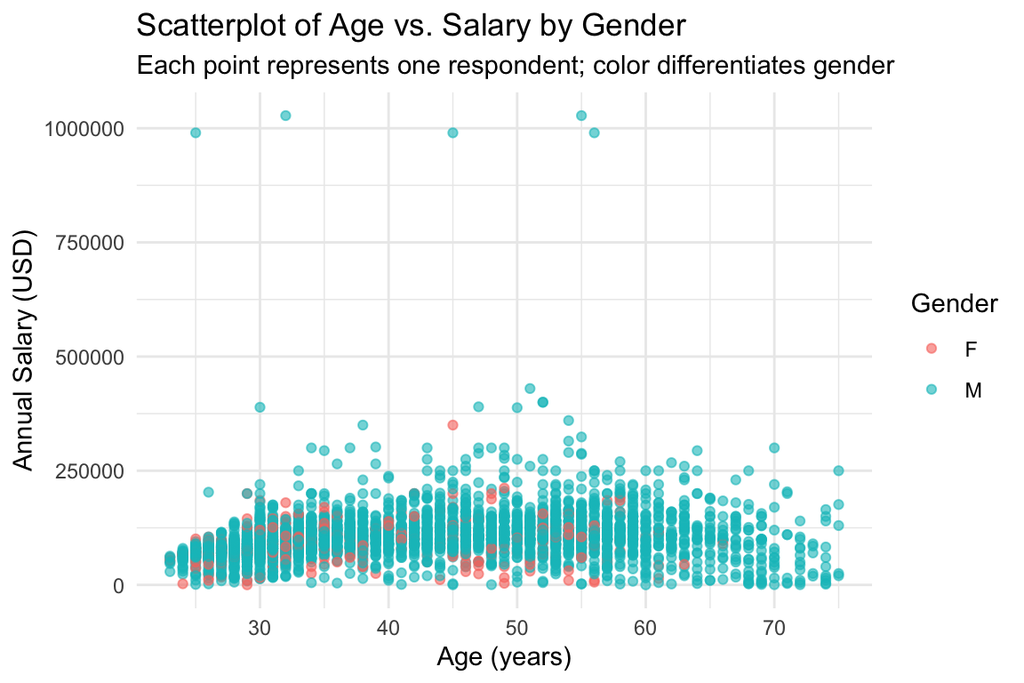

*Bonus point*: Is there a correlation between an engineer’s salary and age? What is the estimated Pearson correlation coefficient *r*? Run a formal test.

```
##
##  Pearson's product-moment correlation
##
## data:  me_clean$age and me_clean$salary
## t = 12.741, df = 3599, p-value < 0.00000000000000022
## alternative hypothesis: true correlation is not equal to 0
## 95 percent confidence interval:
##  0.1762777 0.2387883
## sample estimates:
##       cor
## 0.2077451
```

## Question 6: Cumulative distribution function

Plot the cumulative distribution function of `salary` by `gender`. Adjust the x-axis with `scale_x_log10(limits = c(5e4, 5e5))` to zoom in a bit. What do you notice about the salaries for men and women? Hint: Remember there are greater differences the farther up you go on a log scale axis.

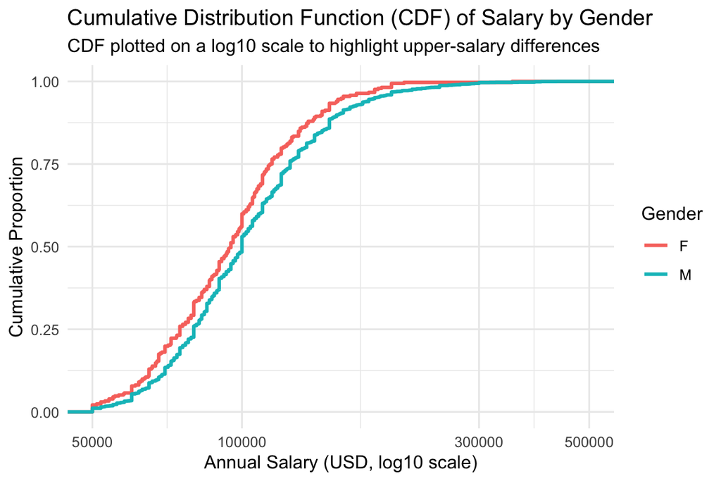

## Question 7: Quantiles

Calculate the quantiles of `salary` by `gender`. You can either subset the data with `dplyr::filter()` and dataframe assignment, or you can group by, summarize by quantile, and ungroup.

*Bonus point*: Assign the output to a dataframe, and use inline code to call individual values when answering the following questions. Do not let R use scientific notation in the text output; check the knitted document.

Salary quantiles by gender

| gender | n | q00 | q25 | q50 | q75 | q90 | q95 | q100 |
| --- | --- | --- | --- | --- | --- | --- | --- | --- |
| F | 373 | $140 | $68,000 | $90,000 | $110,513 | $139,860 | $156,000 | $350,000 |
| M | 3228 | $105 | $75,000 | $97,000 | $123,000 | $155,000 | $184,000 | $1,027,653 |

What is the difference in salary between men and women at the median?

- Median salary for women is $90,000
- Median salary for men is $97,000
- The difference at the median is $7,000

Whatother information would you need to test your hypothesis? More information into the types of jobs and what jobs males and females are getting.

## Question 8: Hypothetical analysis

Think about what other variables you would like to include in an hypothetical analysis. From your perspective, what are the most important individual, family, and workforce factors related to salary—beyond gender and age?

In a broader analysis of engineering salaries, I would include variables that capture individual, family, and workplace factors beyond gender and age. At the individual level, education, experience, certifications, and technical skills are major determinants of pay. Family characteristics such as marital status, dependents, and caregiving responsibilities may influence work choices and career progression. Workforce factors—including industry sector, company size, region, and job title—also shape salary outcomes by reflecting differences in demand, cost of living, and advancement opportunities. Considering these variables together would provide a more complete understanding of what drives salary differences among engineers.

## Question 9: Recreate plot

Recreate this plot with the `mpg` dataset. Remember to use `?mpg` for information on the dataset and the variables. How would you describe the correlation between the independent variable and dependent variable? Do you see any patterns when considering the third variable?

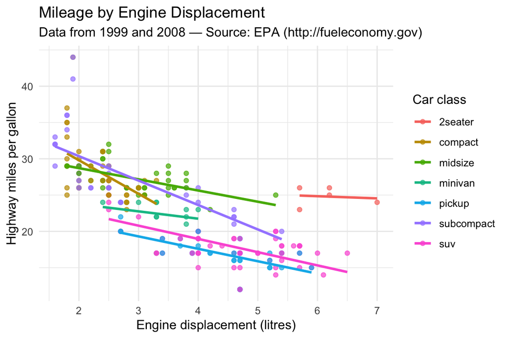

# Appendix

```r
# set global options for figures, code, warnings, and messages
knitr::opts_chunk$set(fig.width=6, fig.height=4, fig.path="../figs/",
                      echo=FALSE, warning=FALSE, message=FALSE)
# load packages for current session
library(tidyverse)
library(janitor)
library(knitr)
library(scales)
options(scipen = 999)

me_clean <- read_csv("ME_salaries.csv") |>
  janitor::clean_names() |>
  mutate(
    gender = as.factor(gender)
  ) |>
  filter(salary != 0)


# number of observations with salary as 0
me_zero_salary <- read_csv("ME_salaries.csv") |>
  janitor::clean_names() |>
  filter(salary == 0)

n_zero_salary <- nrow(me_zero_salary)
n_zero_salary
# number of factor levels
levels(me_clean$gender)
# univariate eda
theme_set(theme_minimal())

glimpse(me_clean)

me_clean |>
ggplot(aes(x = age)) +
geom_histogram(binwidth = 2, fill = "steelblue", color = "white", alpha = 0.8) +
labs(
title = "Distribution of Age among Engineering Graduates",
subtitle = "Most respondents are between their late 20s and 40s",
x = "Age (years)", y = "Count"
)

me_clean |>
summarize(
mean_age = mean(age, na.rm = TRUE),
median_age = median(age, na.rm = TRUE),
sd_age = sd(age, na.rm = TRUE),
min_age = min(age, na.rm = TRUE),
max_age = max(age, na.rm = TRUE)
) |>
kable()

me_clean |>
count(gender) |>
mutate(prop = n / sum(n)) |>
ggplot(aes(x = gender, y = prop, fill = gender)) +
geom_col(alpha = 0.8) +
scale_y_continuous(labels = scales::percent) +
labs(
title = "Gender Distribution of Engineering Graduates",
subtitle = "Proportion of respondents by gender",
x = "Gender", y = "Percent"
) +
theme(legend.position = "none")

me_clean |>
ggplot(aes(x = salary)) +
geom_histogram(binwidth = 5000, fill = "darkseagreen", color = "white", alpha = 0.8) +
labs(
title = "Distribution of Engineering Salaries (2017)",
subtitle = "Right-skewed distribution; many between $60k–$120k",
x = "Annual Salary (USD)", y = "Count"
)

me_clean |>
summarize(
mean_salary = mean(salary, na.rm = TRUE),
median_salary = median(salary, na.rm = TRUE),
sd_salary = sd(salary, na.rm = TRUE),
min_salary = min(salary, na.rm = TRUE),
max_salary = max(salary, na.rm = TRUE)
) |>
kable()

# histogram of salaries split by gender
me_clean |>
ggplot(aes(x = salary, fill = gender)) +
geom_histogram(bins = 50, color = "lightgrey", alpha = 0.8) +
facet_wrap(~ gender) +
labs(
title = "Distribution of Engineering Salaries by Gender",
subtitle = "Histogram faceted by gender, 50 bins, light grey outlines",
x = "Annual Salary (USD)",
y = "Count",
fill = "Gender"
) +
theme_minimal()

# histogram of ages split by gender
me_clean |>
  ggplot(aes(x = age, fill = gender)) +
  geom_histogram(bins = 50, color = "lightgrey", alpha = 0.8) +
  facet_wrap(~ gender) +
  labs(
    title = "Distribution of Age by Gender",
    subtitle = "Histogram faceted by gender, 50 bins, light grey outlines",
    x = "Age (years)",
    y = "Count",
    fill = "Gender"
  ) +
  theme_minimal()

# boxplots of salary data by gender
me_clean |>
  ggplot(aes(x = gender, y = salary, fill = gender)) +
  geom_boxplot(outlier.shape = 1, alpha = 0.7) +
  facet_wrap(~ gender) +
  labs(
    title = "Boxplot of Salary by Gender",
    subtitle = "Boxplots faceted by gender with hollow-circle outliers",
    x = "Gender",
    y = "Annual Salary (USD)",
    fill = "Gender"
  ) +
  theme_minimal() +
  theme(legend.position = "none")

# boxplots of age data by gender
me_clean |>
  ggplot(aes(x = gender, y = age, fill = gender)) +
  geom_boxplot(outlier.shape = 1, alpha = 0.7) +
  facet_wrap(~ gender) +
  labs(
    title = "Boxplot of Age by Gender",
    subtitle = "Boxplots faceted by gender with hollow-circle outliers",
    x = "Gender",
    y = "Age (years)",
    fill = "Gender"
  ) +
  theme_minimal() +
  theme(legend.position = "none")

# scatterplot of salary across age by gender
me_clean |>
  ggplot(aes(x = age, y = salary, color = gender)) +
  geom_point(alpha = 0.6) +
  labs(
    title = "Scatterplot of Age vs. Salary by Gender",
    subtitle = "Each point represents one respondent; color differentiates gender",
    x = "Age (years)",
    y = "Annual Salary (USD)",
    color = "Gender"
  ) +
  theme_minimal()

# correlation test
cor_test_result <- cor.test(me_clean$age, me_clean$salary, method = "pearson")

cor_test_result
# plot cdf of salary by gender

me_clean |>
  ggplot(aes(x = salary, color = gender)) +
  stat_ecdf(size = 1) +
  scale_x_log10(limits = c(5e4, 5e5)) +
  labs(
    title = "Cumulative Distribution Function (CDF) of Salary by Gender",
    subtitle = "CDF plotted on a log10 scale to highlight upper-salary differences",
    x = "Annual Salary (USD, log10 scale)",
    y = "Cumulative Proportion",
    color = "Gender"
  ) +
  theme_minimal()

# calculate quantiles of salary by gender

q_salary_gender <- me_clean |>
  group_by(gender) |>
  summarize(
    n   = n(),
    q00 = quantile(salary, 0.00, na.rm = TRUE),
    q25 = quantile(salary, 0.25, na.rm = TRUE),
    q50 = quantile(salary, 0.50, na.rm = TRUE),  # median
    q75 = quantile(salary, 0.75, na.rm = TRUE),
    q90 = quantile(salary, 0.90, na.rm = TRUE),
    q95 = quantile(salary, 0.95, na.rm = TRUE),
    q100= quantile(salary, 1.00, na.rm = TRUE),
    .groups = "drop"
  )

# Nicely formatted table (no scientific notation)
q_salary_gender_fmt <- q_salary_gender |>
  mutate(across(starts_with("q"), function(x) scales::dollar(x)))

knitr::kable(q_salary_gender_fmt, caption = "Salary quantiles by gender")

# call mpg pdf - you need to recreate it
if (file.exists("mpg-ch7-plot.pdf")) {
  knitr::include_graphics("mpg-ch7-plot.pdf")
} else {
  message("mpg-ch7-plot.pdf not found; skipping.")
}

ggplot(mpg, aes(x = displ, y = hwy, color = class)) +
geom_point(alpha = 0.7) +
geom_smooth(method = "lm", se = FALSE, linewidth = 1) +
labs(
title = "Mileage by Engine Displacement",
subtitle = "Data from 1999 and 2008 — Source: EPA (http://fueleconomy.gov)",
x = "Engine displacement (litres)",
y = "Highway miles per gallon",
color = "Car class"
) +
theme_minimal()
```